# Congruence between independent and dependent SSEs using data generated under CID model

In simulations below, we use abbreviated state labels $b_1, a_1, b_0, a_0, d_0, c_0, d_1, c_1$. These correspond to the states in the main text (A1–1, A1–0, A0–1, A0–0, B0–1, B0–0, B1–1, and B1–0), as shown in Supplementary Figure 1.

```r
##~~~~~~~~~~~~~~~~~~~~~~~~~~~~~~~~~~~~~~~
##  ~ installations and dependencies  ----
##~~~~~~~~~~~~~~~~~~~~~~~~~~~~~~~~~~~~~~~
source('R/utils/dependencies.R')
source('R/hiclasse/HiClaSSE-R.R') # pure R implementation of HiCLaSSE
```

```
## [1] "Original matrix:"
##      [,1] [,2] [,3]
## [1,]    1    4    7
## [2,]    2    5    8
## [3,]    3    6    9
## [1] "Matrix with right diagonal set to zero:"
##      [,1] [,2] [,3]
## [1,]    1    4    0
## [2,]    2    0    8
## [3,]    0    6    9
```

```r
source('R/hiclasse/HiClaSSE_cpp.R') # fast implementation
```

```
## [1] "Original matrix:"
##      [,1] [,2] [,3]
## [1,]    1    4    7
## [2,]    2    5    8
## [3,]    3    6    9
## [1] "Matrix with right diagonal set to zero:"
##      [,1] [,2] [,3]
## [1,]    1    4    0
## [2,]    2    0    8
## [3,]    0    6    9
## [1] TRUE
## [1] TRUE
## [1] TRUE
## [1] TRUE
```

## Read in data

```r
NSIM = 10
phy <- readRDS(file='R/data/sim/phy_CID4-10tr.RDS')
```

## Setting-up Q matrices for inference

### CID4

```r
# trait
Q_t <- initQ(c(0,1), c(.1, .1))

# diversification regime
Q_r2 <- initQ(c('A','B'), c(.1,.1))


# speciation rates for tracking the order
La4 <- diag(c(-0.1,-0.05),2)
La4 = La4 %x% diag(1,2)
# order according to regimes
Q_cid4.r <- amaSMM(Q_r2, Q_t)

# order according to trait
v=c(1,3, 2,4)
Q_cid4.t <- Q_cid4.r[v,v]

print(Q_cid4.r)
```

```
##      A0   A1   B0   B1
## A0 -0.2  0.1  0.1  0.0
## A1  0.1 -0.2  0.0  0.1
## B0  0.1  0.0 -0.2  0.1
## B1  0.0  0.1  0.1 -0.2
```

```r
print(La4)
```

```
##      [,1] [,2]  [,3]  [,4]
## [1,] -0.1  0.0  0.00  0.00
## [2,]  0.0 -0.1  0.00  0.00
## [3,]  0.0  0.0 -0.05  0.00
## [4,]  0.0  0.0  0.00 -0.05
```

```r
print(Q_cid4.t)
```

```
##      A0   B0   A1   B1
## A0 -0.2  0.1  0.1  0.0
## B0  0.1 -0.2  0.0  0.1
## A1  0.1  0.0 -0.2  0.1
## B1  0.0  0.1  0.1 -0.2
```

```r
print(La4[v,v])
```

```
##      [,1]  [,2] [,3]  [,4]
## [1,] -0.1  0.00  0.0  0.00
## [2,]  0.0 -0.05  0.0  0.00
## [3,]  0.0  0.00 -0.1  0.00
## [4,]  0.0  0.00  0.0 -0.05
```

### CID8 (congruent to CID4)

```r
# diversification regime
#Q_r4 <- initQ(c('a','b', 'c', 'd'), c(.01,.01))

Q_r4 <-amaSMM(Q_t, Q_t)
colnames(Q_r4) <- rownames(Q_r4) <- c('a','b', 'c', 'd')

# speciation rates for tracking the order
La8 <- diag(c(-0.1,-0.05),2)
La8 = La8 %x% diag(1,4)

# order according to regimes
Q_cid8.r <- amaSMM(Q_r4, Q_t)

# order according to trait
v=c(1,3,5,7, 2,4,6,8)
Q_cid8.t <- Q_cid8.r[v,v]

print(Q_cid8.r)
```

```
##      a0   a1   b0   b1   c0   c1   d0   d1
## a0 -0.3  0.1  0.1  0.0  0.1  0.0  0.0  0.0
## a1  0.1 -0.3  0.0  0.1  0.0  0.1  0.0  0.0
## b0  0.1  0.0 -0.3  0.1  0.0  0.0  0.1  0.0
## b1  0.0  0.1  0.1 -0.3  0.0  0.0  0.0  0.1
## c0  0.1  0.0  0.0  0.0 -0.3  0.1  0.1  0.0
## c1  0.0  0.1  0.0  0.0  0.1 -0.3  0.0  0.1
## d0  0.0  0.0  0.1  0.0  0.1  0.0 -0.3  0.1
## d1  0.0  0.0  0.0  0.1  0.0  0.1  0.1 -0.3
```

```r
print(La8)
```

```
##      [,1] [,2] [,3] [,4]  [,5]  [,6]  [,7]  [,8]
## [1,] -0.1  0.0  0.0  0.0  0.00  0.00  0.00  0.00
## [2,]  0.0 -0.1  0.0  0.0  0.00  0.00  0.00  0.00
## [3,]  0.0  0.0 -0.1  0.0  0.00  0.00  0.00  0.00
## [4,]  0.0  0.0  0.0 -0.1  0.00  0.00  0.00  0.00
## [5,]  0.0  0.0  0.0  0.0 -0.05  0.00  0.00  0.00
## [6,]  0.0  0.0  0.0  0.0  0.00 -0.05  0.00  0.00
## [7,]  0.0  0.0  0.0  0.0  0.00  0.00 -0.05  0.00
## [8,]  0.0  0.0  0.0  0.0  0.00  0.00  0.00 -0.05
```

```r
print(Q_cid8.t)
```

```
##      a0   b0   c0   d0   a1   b1   c1   d1
## a0 -0.3  0.1  0.1  0.0  0.1  0.0  0.0  0.0
## b0  0.1 -0.3  0.0  0.1  0.0  0.1  0.0  0.0
## c0  0.1  0.0 -0.3  0.1  0.0  0.0  0.1  0.0
## d0  0.0  0.1  0.1 -0.3  0.0  0.0  0.0  0.1
## a1  0.1  0.0  0.0  0.0 -0.3  0.1  0.1  0.0
## b1  0.0  0.1  0.0  0.0  0.1 -0.3  0.0  0.1
## c1  0.0  0.0  0.1  0.0  0.1  0.0 -0.3  0.1
## d1  0.0  0.0  0.0  0.1  0.0  0.1  0.1 -0.3
```

```r
print(La8[v,v])
```

```
##      [,1] [,2]  [,3]  [,4] [,5] [,6]  [,7]  [,8]
## [1,] -0.1  0.0  0.00  0.00  0.0  0.0  0.00  0.00
## [2,]  0.0 -0.1  0.00  0.00  0.0  0.0  0.00  0.00
## [3,]  0.0  0.0 -0.05  0.00  0.0  0.0  0.00  0.00
## [4,]  0.0  0.0  0.00 -0.05  0.0  0.0  0.00  0.00
## [5,]  0.0  0.0  0.00  0.00 -0.1  0.0  0.00  0.00
## [6,]  0.0  0.0  0.00  0.00  0.0 -0.1  0.00  0.00
## [7,]  0.0  0.0  0.00  0.00  0.0  0.0 -0.05  0.00
## [8,]  0.0  0.0  0.00  0.00  0.0  0.0  0.00 -0.05
```

### COR8-C (correlated evolution, congruent to CID4)

```r
# like CID8 but with correlation
Q_cor8_C.t <- Q_cid8.t


# Q_cor8_C.t['b0', 'd0'] <- 0
# Q_cor8_C.t['b0', 'c0'] <- 0.1
Q_cor8_C.t['b1', 'd1'] <- 0
Q_cor8_C.t['b1', 'c1'] <- 0.1

v=c(1,5, 2,6, 3,7, 4,8)
Q_cor8_C.r <- Q_cor8_C.t[v,v]

print(Q_cor8_C.r*10)
```

```
##    a0 a1 b0 b1 c0 c1 d0 d1
## a0 -3  1  1  0  1  0  0  0
## a1  1 -3  0  1  0  1  0  0
## b0  1  0 -3  1  0  0  1  0
## b1  0  1  1 -3  0  1  0  0
## c0  1  0  0  0 -3  1  1  0
## c1  0  1  0  0  1 -3  0  1
## d0  0  0  1  0  1  0 -3  1
## d1  0  0  0  1  0  1  1 -3
```

```r
#print(La8)
print(Q_cor8_C.t*10)
```

```
##    a0 b0 c0 d0 a1 b1 c1 d1
## a0 -3  1  1  0  1  0  0  0
## b0  1 -3  0  1  0  1  0  0
## c0  1  0 -3  1  0  0  1  0
## d0  0  1  1 -3  0  0  0  1
## a1  1  0  0  0 -3  1  1  0
## b1  0  1  0  0  1 -3  1  0
## c1  0  0  1  0  1  0 -3  1
## d1  0  0  0  1  0  1  1 -3
```

```r
#print(La8[v,v])

# Plot the graph
# g <- create_graph_from_matrix(Q_cor8_C.t)
# unidirectional_edges <- is_unidirectional(g)
# plot(g, vertex.label = V(g)$name, vertex.size = 30, edge.color = ifelse(unidirectional_edges, "red", "black"))
```

### COR8-NC (Correlated evolution, noncongruent to CID4)

```r
# not congruent
Q_cor8_NC.t <- Q_cid8.t

# Q_cor8_NC.t['b0', 'd0'] <- 0
# Q_cor8_NC.t['b0', 'c0'] <- 0

Q_cor8_NC.t['b1', 'd1'] <- 0
Q_cor8_NC.t['b1', 'c1'] <- 0


v=c(1,5, 2,6, 3,7, 4,8)
Q_cor8_NC.r <- Q_cor8_NC.t[v,v]

print(Q_cor8_NC.r*10)
```

```
##    a0 a1 b0 b1 c0 c1 d0 d1
## a0 -3  1  1  0  1  0  0  0
## a1  1 -3  0  1  0  1  0  0
## b0  1  0 -3  1  0  0  1  0
## b1  0  1  1 -3  0  0  0  0
## c0  1  0  0  0 -3  1  1  0
## c1  0  1  0  0  1 -3  0  1
## d0  0  0  1  0  1  0 -3  1
## d1  0  0  0  1  0  1  1 -3
```

```r
#print(La8)
print(Q_cor8_NC.t*10)
```

```
##    a0 b0 c0 d0 a1 b1 c1 d1
## a0 -3  1  1  0  1  0  0  0
## b0  1 -3  0  1  0  1  0  0
## c0  1  0 -3  1  0  0  1  0
## d0  0  1  1 -3  0  0  0  1
## a1  1  0  0  0 -3  1  1  0
## b1  0  1  0  0  1 -3  0  0
## c1  0  0  1  0  1  0 -3  1
## d1  0  0  0  1  0  1  1 -3
```

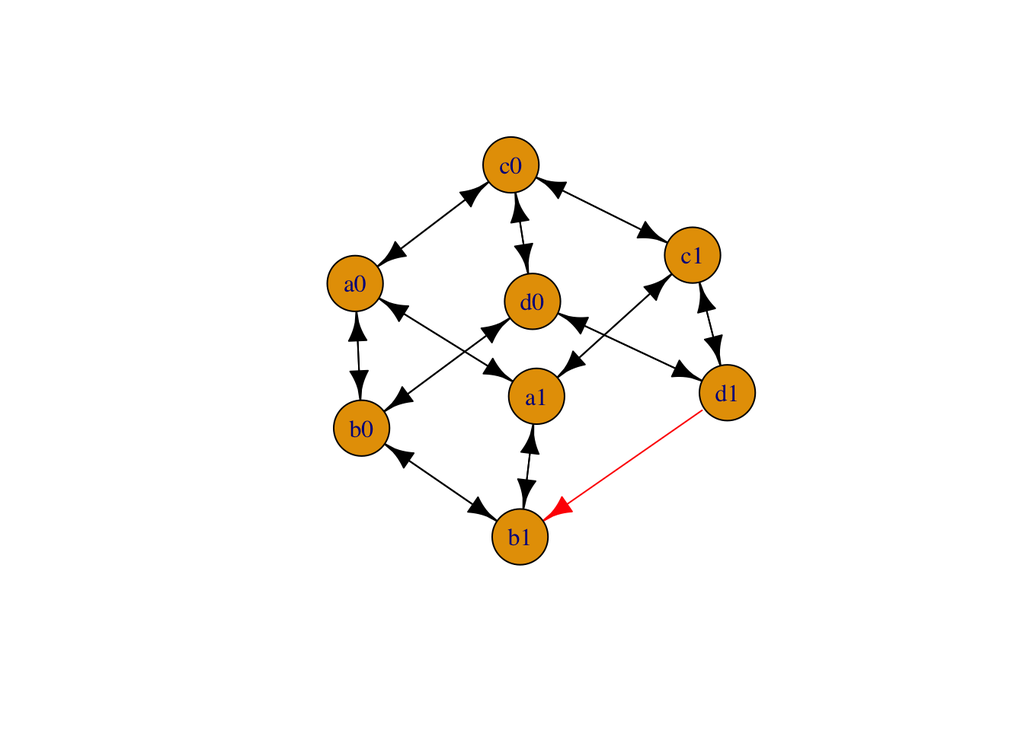

```r
#print(La8[v,v])

# Plot the graph
g <- create_graph_from_matrix(Q_cor8_NC.t)
unidirectional_edges <- is_unidirectional(g)
plot(g, vertex.label = V(g)$name, vertex.size = 30, edge.color = ifelse(unidirectional_edges, "red", "black"))
```

## Irreducible model: CID4 (4 pars)

```r
Args <- list(
  Nstates = 4L,
  y = list(
    c(0,0,0,0, 1,0,1,0),
    c(0,0,0,0, 0,1,0,1)
  ))

newArgs <- makeArgs(Args)
#printArgsGlobal()
args <- argnames_HiClaSSE(4)
#args$arrays
#args$pars
# length(args$pars) # 56
#length(args$pars)
reoder_lambdas(args$arrays, c(1,3, 2,4))
```

```
## $lam.tensor
## $lam.tensor[[1]]
##      [,1]     [,2]     [,3]     [,4]
## [1,] "lam000" "lam002" "lam001" "lam003"
## [2,] "0"      "lam022" "0"      "lam023"
## [3,] "0"      "lam012" "lam011" "lam013"
## [4,] "0"      "0"      "0"      "lam033"
##
## $lam.tensor[[2]]
##      [,1]     [,2]     [,3]     [,4]
## [1,] "lam200" "lam202" "lam201" "lam203"
## [2,] "0"      "lam222" "0"      "lam223"
## [3,] "0"      "lam212" "lam211" "lam213"
## [4,] "0"      "0"      "0"      "lam233"
##
## $lam.tensor[[3]]
##      [,1]     [,2]     [,3]     [,4]
## [1,] "lam100" "lam102" "lam101" "lam103"
## [2,] "0"      "lam122" "0"      "lam123"
## [3,] "0"      "lam112" "lam111" "lam113"
## [4,] "0"      "0"      "0"      "lam133"
##
## $lam.tensor[[4]]
##      [,1]     [,2]     [,3]     [,4]
## [1,] "lam300" "lam302" "lam301" "lam303"
## [2,] "0"      "lam322" "0"      "lam323"
## [3,] "0"      "lam312" "lam311" "lam313"
## [4,] "0"      "0"      "0"      "lam333"
##
##
## $mu
## [1] "mu0" "mu2" "mu1" "mu3"
##
## $Q
##      [,1]  [,2]  [,3]  [,4]
## [1,] "0"   "q02" "q01" "q03"
## [2,] "q20" "0"   "q21" "q23"
## [3,] "q10" "q12" "0"   "q13"
## [4,] "q30" "q32" "q31" "0"
```

```r
pars.hc <- rep(0, length(args$pars))
names(pars.hc) <- args$pars
pars.hc['lam000'] <- 0.1
pars.hc['lam111'] <- 0.1
pars.hc['lam222'] <- 0.05
pars.hc['lam333'] <- 0.05
pars.hc['mu0'] <-pars.hc['mu1'] <- pars.hc['mu2'] <- pars.hc['mu3'] <-0.1
qs <- extract_off_diagonal(Q_cid4.r)
qsl=length(qs)
pars.hc[c(length(pars.hc)-qsl+1):length(pars.hc)] <- qs

#pars.hc
#pars_to_arrays(pars.hc,4)
#args

zero.constr <- formulas_zero_pars(pars.hc)
f.qs <- assign_classes_pairwise(Q_cid4.r, args$arrays$Q)
f.mu <- c(mu1 ~ mu0, mu2 ~ mu0, mu3 ~ mu0)
f.lams <- c(lam111 ~ lam000, lam333 ~ lam222)
f.list<- c(zero.constr,  f.qs, f.mu, f.lams)
```

Run inference

```r
CID4 <- list()
i=1
for (i in 1:NSIM){
  print(paste0('Working on: ', i))
  tree <- phy[[i]]
  states<- tree$tip.state
  states<- mapvalues(states, from = c("0", "1", "2", "3"), to=c(0, 1, 0, 1) )
  root <- c(1/4, 1/4, 1/4, 1/4)

  lik.c <- make.HiClasse_cpp(tree, states,  sampling.f=NULL,  strict=TRUE, control=list(backend = "gslode"), newArgs)
  lik.const <- constrain(lik.c, formulae = f.list)
  arg.const <- argnames(lik.const)
  starting.point <- pars.hc[arg.const]
  CID4[[i]] <- find.mle(lik.const, starting.point, method="subplex", keep.func=F, root=ROOT.GIVEN, root.p=root, condition.surv=TRUE)
}
```

```
## [1] "Working on: 1"
## [1] "Recoding: 0010 -> 00001010"
## [1] "Recoding: 0001 -> 00000101"
## [1] "Working on: 2"
## [1] "Recoding: 0010 -> 00001010"
## [1] "Recoding: 0001 -> 00000101"
## [1] "Working on: 3"
## [1] "Recoding: 0010 -> 00001010"
## [1] "Recoding: 0001 -> 00000101"
## [1] "Working on: 4"
## [1] "Recoding: 0010 -> 00001010"
## [1] "Recoding: 0001 -> 00000101"
## [1] "Working on: 5"
## [1] "Recoding: 0010 -> 00001010"
## [1] "Recoding: 0001 -> 00000101"
## [1] "Working on: 6"
## [1] "Recoding: 0010 -> 00001010"
## [1] "Recoding: 0001 -> 00000101"
## [1] "Working on: 7"
## [1] "Recoding: 0010 -> 00001010"
## [1] "Recoding: 0001 -> 00000101"
## [1] "Working on: 8"
## [1] "Recoding: 0010 -> 00001010"
## [1] "Recoding: 0001 -> 00000101"
## [1] "Working on: 9"
## [1] "Recoding: 0010 -> 00001010"
## [1] "Recoding: 0001 -> 00000101"
## [1] "Working on: 10"
## [1] "Recoding: 0010 -> 00001010"
## [1] "Recoding: 0001 -> 00000101"
```

Some helper functions to assess the inference parameters.

```r
get_item(CID4, 'lnLik')
```

```
##  [1] -455.2889 -421.5108 -436.2586 -433.9500 -435.4874 -431.6472 -431.5324
##  [8] -412.9655 -409.6720 -437.6128
```

```r
#pars_to_arrays(CID4[[1]]$par.full, 4) %>% reoder_lambdas(., c(1,3, 2,4))
#get_item(CID4[1], 'par')
```

Print nice to show matrix structure only

```r
# CID4[[1]]$par
pp <- round(CID4[[1]]$par.full*100, 1)
X <- pars_to_arrays(pp, 4) %>% reoder_lambdas(., c(1,3, 2,4))
X <- names2array(X, c('A0',   'B0',   'A1',   'B1'))
```

## Inferences using parameters from CID4

### CID8 (4 pars)

```r
Args <- list(
  Nstates = 8L,
  y = list(
    c(0,0,0,0,0,0,0,0, 1,0,1,0,1,0,1,0),
    c(0,0,0,0,0,0,0,0, 0,1,0,1,0,1,0,1)
  ))

newArgs <- makeArgs(Args)
#printArgsGlobal()
args <- argnames_HiClaSSE(8)
#args$arrays
#reoder_lambdas(args$arrays, c(1,3,5,7, 2,4,6,8))
```

Run inference

```r
CID8.pars <- list()
i=1
for (i in 1:NSIM){
  print(paste0('Working on: ', i))
  #-----------
  est <- get_item(CID4[i], 'par')
  pars.hc <- rep(0, length(args$pars))
  names(pars.hc) <- args$pars
  pars.hc['lam000'] <- est['lam000']
  pars.hc['lam111'] <- est['lam000']
  pars.hc['lam222'] <- est['lam000']
  pars.hc['lam333'] <- est['lam000']
  pars.hc['lam444'] <- est['lam222']
  pars.hc['lam555'] <- est['lam222']
  pars.hc['lam666'] <- est['lam222']
  pars.hc['lam777'] <- est['lam222']
  pars.hc['mu0'] <-pars.hc['mu1'] <- pars.hc['mu2'] <- pars.hc['mu3'] <- pars.hc['mu4']<- pars.hc['mu5']<- pars.hc['mu6']<- pars.hc['mu7'] <- est['mu0']
  qs <- extract_off_diagonal(Q_cid8.r)
  qsl=length(qs)
  qs[qs==0.1] <- est['q01']
  qs[qs==0.01] <- est['q02']/2
  pars.hc[c(length(pars.hc)-qsl+1):length(pars.hc)] <- qs

  #pars.hc
  #pars_to_arrays(pars.hc, 8)
  #------
  tree <- phy[[i]]
  states<- tree$tip.state
  states<- mapvalues(states, from = c("0", "1", "2", "3"), to=c(0, 1, 0, 1) )
  root <- rep(1/8, 8)

  lik.c <- make.HiClasse_cpp(tree, states,  sampling.f=NULL,  strict=TRUE, control=list(backend = "gslode"), newArgs)
  CID8.pars[[i]] <- lik.c(pars.hc, intermediates=F, root=ROOT.GIVEN, root.p=root, condition.surv=T)

}
```

```
## [1] "Working on: 1"
## [1] "Recoding: 0010 -> 0000000010101010"
## [1] "Recoding: 0001 -> 0000000001010101"
## [1] "Working on: 2"
## [1] "Recoding: 0010 -> 0000000010101010"
## [1] "Recoding: 0001 -> 0000000001010101"
## [1] "Working on: 3"
## [1] "Recoding: 0010 -> 0000000010101010"
## [1] "Recoding: 0001 -> 0000000001010101"
## [1] "Working on: 4"
## [1] "Recoding: 0010 -> 0000000010101010"
## [1] "Recoding: 0001 -> 0000000001010101"
## [1] "Working on: 5"
## [1] "Recoding: 0010 -> 0000000010101010"
## [1] "Recoding: 0001 -> 0000000001010101"
## [1] "Working on: 6"
## [1] "Recoding: 0010 -> 0000000010101010"
## [1] "Recoding: 0001 -> 0000000001010101"
## [1] "Working on: 7"
## [1] "Recoding: 0010 -> 0000000010101010"
## [1] "Recoding: 0001 -> 0000000001010101"
## [1] "Working on: 8"
## [1] "Recoding: 0010 -> 0000000010101010"
## [1] "Recoding: 0001 -> 0000000001010101"
## [1] "Working on: 9"
## [1] "Recoding: 0010 -> 0000000010101010"
## [1] "Recoding: 0001 -> 0000000001010101"
## [1] "Working on: 10"
## [1] "Recoding: 0010 -> 0000000010101010"
## [1] "Recoding: 0001 -> 0000000001010101"
```

Compare Ln

```r
get_item(CID4, 'lnLik')
```

```
##  [1] -455.2889 -421.5108 -436.2586 -433.9500 -435.4874 -431.6472 -431.5324
##  [8] -412.9655 -409.6720 -437.6128
```

```r
CID8.pars %>% unlist
```

```
##  [1] -455.2889 -421.5108 -436.2586 -433.9500 -435.4874 -431.6472 -431.5324
##  [8] -412.9655 -409.6720 -437.6128
```

```r
# pars_to_arrays(pars.hc, 8) %>% reoder_lambdas(., c(1,3,5,7, 2,4,6,8))
```

### COR8-C (4 pars)

```r
Args <- list(
  Nstates = 8L,
  y = list(
    c(0,0,0,0,0,0,0,0, 1,0,1,0,1,0,1,0),
    c(0,0,0,0,0,0,0,0, 0,1,0,1,0,1,0,1)
  ))

newArgs <- makeArgs(Args)
#printArgsGlobal()
args <- argnames_HiClaSSE(8)
#args
```

Run inference

```r
COR8_C.pars <- list()
i=2
for (i in 1:NSIM){
  print(paste0('Working on: ', i))
  #-----------
  est <- get_item(CID4[i], 'par')
  pars.hc <- rep(0, length(args$pars))
  names(pars.hc) <- args$pars
  pars.hc['lam000'] <- est['lam000']
  pars.hc['lam111'] <- est['lam000']
  pars.hc['lam222'] <- est['lam000']
  pars.hc['lam333'] <- est['lam000']
  pars.hc['lam444'] <- est['lam222']
  pars.hc['lam555'] <- est['lam222']
  pars.hc['lam666'] <- est['lam222']
  pars.hc['lam777'] <- est['lam222']
  pars.hc['mu0'] <-pars.hc['mu1'] <- pars.hc['mu2'] <- pars.hc['mu3'] <- pars.hc['mu4']<- pars.hc['mu5']<- pars.hc['mu6']<- pars.hc['mu7'] <- est['mu0']
  qs <- extract_off_diagonal(Q_cor8_C.r)
  qsl=length(qs)
  qs[qs==0.1] <- est['q01']
  qs[qs==0.01] <- est['q02']/2
  pars.hc[c(length(pars.hc)-qsl+1):length(pars.hc)] <- qs

  # pars.hc
  # pars_to_arrays(pars.hc, 8)
  #v=c(1,3,5,7, 2,4,6,8)
  #pars_to_arrays(pars.hc, 8)$Q[v,v]

  #------
  tree <- phy[[i]]
  states<- tree$tip.state
  states<- mapvalues(states, from = c("0", "1", "2", "3"), to=c(0, 1, 0, 1) )
  root <- rep(1/8, 8)

  lik.c <- make.HiClasse_cpp(tree, states,  sampling.f=NULL,  strict=TRUE, control=list(backend = "gslode"), newArgs)
  COR8_C.pars[[i]] <- lik.c(pars.hc, intermediates=F, root=ROOT.GIVEN, root.p=root, condition.surv=T)

}
```

```
## [1] "Working on: 1"
## [1] "Recoding: 0010 -> 0000000010101010"
## [1] "Recoding: 0001 -> 0000000001010101"
## [1] "Working on: 2"
## [1] "Recoding: 0010 -> 0000000010101010"
## [1] "Recoding: 0001 -> 0000000001010101"
## [1] "Working on: 3"
## [1] "Recoding: 0010 -> 0000000010101010"
## [1] "Recoding: 0001 -> 0000000001010101"
## [1] "Working on: 4"
## [1] "Recoding: 0010 -> 0000000010101010"
## [1] "Recoding: 0001 -> 0000000001010101"
## [1] "Working on: 5"
## [1] "Recoding: 0010 -> 0000000010101010"
## [1] "Recoding: 0001 -> 0000000001010101"
## [1] "Working on: 6"
## [1] "Recoding: 0010 -> 0000000010101010"
## [1] "Recoding: 0001 -> 0000000001010101"
## [1] "Working on: 7"
## [1] "Recoding: 0010 -> 0000000010101010"
## [1] "Recoding: 0001 -> 0000000001010101"
## [1] "Working on: 8"
## [1] "Recoding: 0010 -> 0000000010101010"
## [1] "Recoding: 0001 -> 0000000001010101"
## [1] "Working on: 9"
## [1] "Recoding: 0010 -> 0000000010101010"
## [1] "Recoding: 0001 -> 0000000001010101"
## [1] "Working on: 10"
## [1] "Recoding: 0010 -> 0000000010101010"
## [1] "Recoding: 0001 -> 0000000001010101"
```

Compare Ln

```r
get_item(CID4, 'lnLik')
```

```
##  [1] -455.2889 -421.5108 -436.2586 -433.9500 -435.4874 -431.6472 -431.5324
##  [8] -412.9655 -409.6720 -437.6128
```

```r
COR8_C.pars %>% unlist
```

```
##  [1] -455.2889 -421.5108 -436.2586 -433.9500 -435.4874 -431.6472 -431.5324
##  [8] -412.9655 -409.6720 -437.6128
```

```r
#pars_to_arrays(pars.hc, 8) %>% reoder_lambdas(., c(1,3,5,7, 2,4,6,8))
```

### COR8-NC (4 pars)

```r
Args <- list(
  Nstates = 8L,
  y = list(
    c(0,0,0,0,0,0,0,0, 1,0,1,0,1,0,1,0),
    c(0,0,0,0,0,0,0,0, 0,1,0,1,0,1,0,1)
  ))

newArgs <- makeArgs(Args)
#printArgsGlobal()
args <- argnames_HiClaSSE(8)
#args
```

Run inference

```r
COR8_NC.pars <- list()
i=1
for (i in 1:NSIM){
  print(paste0('Working on: ', i))
  #-----------
  est <- get_item(CID4[i], 'par')
  pars.hc <- rep(0, length(args$pars))
  names(pars.hc) <- args$pars
  pars.hc['lam000'] <- est['lam000']
  pars.hc['lam111'] <- est['lam000']
  pars.hc['lam222'] <- est['lam000']
  pars.hc['lam333'] <- est['lam000']
  pars.hc['lam444'] <- est['lam222']
  pars.hc['lam555'] <- est['lam222']
  pars.hc['lam666'] <- est['lam222']
  pars.hc['lam777'] <- est['lam222']
  pars.hc['mu0'] <-pars.hc['mu1'] <- pars.hc['mu2'] <- pars.hc['mu3'] <- pars.hc['mu4']<- pars.hc['mu5']<- pars.hc['mu6']<- pars.hc['mu7'] <- est['mu0']
  qs <- extract_off_diagonal(Q_cor8_NC.r)
  qsl=length(qs)
  qs[qs==0.1] <- est['q01']
  qs[qs==0.01] <- est['q02']/2
  pars.hc[c(length(pars.hc)-qsl+1):length(pars.hc)] <- qs

  # pars.hc
  # pars_to_arrays(pars.hc, 8)
  # v=c(1,3,5,7, 2,4,6,8)
  # pars_to_arrays(pars.hc, 8)$Q[v,v]

  #------
  tree <- phy[[i]]
  states<- tree$tip.state
  states<- mapvalues(states, from = c("0", "1", "2", "3"), to=c(0, 1, 0, 1) )
  root <- rep(1/8, 8)

  lik.c <- make.HiClasse_cpp(tree, states,  sampling.f=NULL,  strict=TRUE, control=list(backend = "gslode"), newArgs)
  COR8_NC.pars[[i]] <- lik.c(pars.hc, intermediates=F, root=ROOT.GIVEN, root.p=root, condition.surv=T)

}
```

```
## [1] "Working on: 1"
## [1] "Recoding: 0010 -> 0000000010101010"
## [1] "Recoding: 0001 -> 0000000001010101"
## [1] "Working on: 2"
## [1] "Recoding: 0010 -> 0000000010101010"
## [1] "Recoding: 0001 -> 0000000001010101"
## [1] "Working on: 3"
## [1] "Recoding: 0010 -> 0000000010101010"
## [1] "Recoding: 0001 -> 0000000001010101"
## [1] "Working on: 4"
## [1] "Recoding: 0010 -> 0000000010101010"
## [1] "Recoding: 0001 -> 0000000001010101"
## [1] "Working on: 5"
## [1] "Recoding: 0010 -> 0000000010101010"
## [1] "Recoding: 0001 -> 0000000001010101"
## [1] "Working on: 6"
## [1] "Recoding: 0010 -> 0000000010101010"
## [1] "Recoding: 0001 -> 0000000001010101"
## [1] "Working on: 7"
## [1] "Recoding: 0010 -> 0000000010101010"
## [1] "Recoding: 0001 -> 0000000001010101"
## [1] "Working on: 8"
## [1] "Recoding: 0010 -> 0000000010101010"
## [1] "Recoding: 0001 -> 0000000001010101"
## [1] "Working on: 9"
## [1] "Recoding: 0010 -> 0000000010101010"
## [1] "Recoding: 0001 -> 0000000001010101"
## [1] "Working on: 10"
## [1] "Recoding: 0010 -> 0000000010101010"
## [1] "Recoding: 0001 -> 0000000001010101"
```

Some helper function to assess the inference parameters

```r
get_item(CID4, 'lnLik')
```

```
##  [1] -455.2889 -421.5108 -436.2586 -433.9500 -435.4874 -431.6472 -431.5324
##  [8] -412.9655 -409.6720 -437.6128
```

```r
COR8_NC.pars %>% unlist
```

```
##  [1] -455.2896 -421.5107 -436.2586 -433.8988 -435.4870 -431.6472 -432.0174
##  [8] -412.9655 -409.6259 -437.4800
```

```r
#pars_to_arrays(pars.hc, 8) %>% reoder_lambdas(., c(1,3,5,7, 2,4,6,8))
```

### CLA8-C (4 pars)

```r
Args <- list(
  Nstates = 8L,
  y = list(
    c(0,0,0,0,0,0,0,0, 1,0,1,0,1,0,1,0),
    c(0,0,0,0,0,0,0,0, 0,1,0,1,0,1,0,1)
  ))

newArgs <- makeArgs(Args)
#printArgsGlobal()
args <- argnames_HiClaSSE(8)
#args$arrays
#reoder_lambdas(args$arrays, c(1,3,5,7, 2,4,6,8))
```

Run inference

```r
CLA8_C.pars <- list()
i=1
for (i in 1:NSIM){
  print(paste0('Working on: ', i))
  #-----------
  est <- get_item(CID4[i], 'par')
  pars.hc <- rep(0, length(args$pars))
  names(pars.hc) <- args$pars
  pars.hc['lam022'] <- est['lam000']
  pars.hc['lam133'] <- est['lam000']
  pars.hc['lam202'] <- est['lam000']
  pars.hc['lam311'] <- est['lam000']
  pars.hc['lam466'] <- est['lam222']
  pars.hc['lam577'] <- est['lam222']
  pars.hc['lam646'] <- est['lam222']
  pars.hc['lam757'] <- est['lam222']
  pars.hc['mu0'] <-pars.hc['mu1'] <- pars.hc['mu2'] <- pars.hc['mu3'] <- pars.hc['mu4']<- pars.hc['mu5']<- pars.hc['mu6']<- pars.hc['mu7'] <- est['mu0']
  qs <- extract_off_diagonal(Q_cor8_C.r)
  qsl=length(qs)
  qs[qs==0.1] <- est['q01']
  qs[qs==0.01] <- est['q02']/2
  pars.hc[c(length(pars.hc)-qsl+1):length(pars.hc)] <- qs

  # pars.hc
  # pars_to_arrays(pars.hc, 8)
  # v=c(1,3,5,7, 2,4,6,8)
  # pars_to_arrays(pars.hc, 8)$Q[v,v]

  #------
  tree <- phy[[i]]
  states<- tree$tip.state
  states<- mapvalues(states, from = c("0", "1", "2", "3"), to=c(0, 1, 0, 1) )
  root <- rep(1/8, 8)

  lik.c <- make.HiClasse_cpp(tree, states,  sampling.f=NULL,  strict=TRUE, control=list(backend = "gslode"), newArgs)
  CLA8_C.pars[[i]] <- lik.c(pars.hc, intermediates=F, root=ROOT.GIVEN, root.p=root, condition.surv=T)

}
```

```
## [1] "Working on: 1"
## [1] "Recoding: 0010 -> 0000000010101010"
## [1] "Recoding: 0001 -> 0000000001010101"
## [1] "Working on: 2"
## [1] "Recoding: 0010 -> 0000000010101010"
## [1] "Recoding: 0001 -> 0000000001010101"
## [1] "Working on: 3"
## [1] "Recoding: 0010 -> 0000000010101010"
## [1] "Recoding: 0001 -> 0000000001010101"
## [1] "Working on: 4"
## [1] "Recoding: 0010 -> 0000000010101010"
## [1] "Recoding: 0001 -> 0000000001010101"
## [1] "Working on: 5"
## [1] "Recoding: 0010 -> 0000000010101010"
## [1] "Recoding: 0001 -> 0000000001010101"
## [1] "Working on: 6"
## [1] "Recoding: 0010 -> 0000000010101010"
## [1] "Recoding: 0001 -> 0000000001010101"
## [1] "Working on: 7"
## [1] "Recoding: 0010 -> 0000000010101010"
## [1] "Recoding: 0001 -> 0000000001010101"
## [1] "Working on: 8"
## [1] "Recoding: 0010 -> 0000000010101010"
## [1] "Recoding: 0001 -> 0000000001010101"
## [1] "Working on: 9"
## [1] "Recoding: 0010 -> 0000000010101010"
## [1] "Recoding: 0001 -> 0000000001010101"
## [1] "Working on: 10"
## [1] "Recoding: 0010 -> 0000000010101010"
## [1] "Recoding: 0001 -> 0000000001010101"
```

Some helper function to assess the inference parameters

```r
get_item(CID4, 'lnLik')
```

```
##  [1] -455.2889 -421.5108 -436.2586 -433.9500 -435.4874 -431.6472 -431.5324
##  [8] -412.9655 -409.6720 -437.6128
```

```r
CLA8_C.pars %>% unlist
```

```
##  [1] -455.2889 -421.5108 -436.2586 -433.9500 -435.4874 -431.6472 -431.5324
##  [8] -412.9655 -409.6720 -437.6128
```

```r
#pars_to_arrays(pars.hc, 8) %>% reoder_lambdas(., c(1,3,5,7, 2,4,6,8))
```

### CLA8-NC (4 pars)

```r
Args <- list(
  Nstates = 8L,
  y = list(
    c(0,0,0,0,0,0,0,0, 1,0,1,0,1,0,1,0),
    c(0,0,0,0,0,0,0,0, 0,1,0,1,0,1,0,1)
  ))

newArgs <- makeArgs(Args)
#printArgsGlobal()
args <- argnames_HiClaSSE(8)
#args$arrays
#v=c(1,3,5,7, 2,4,6,8)
#reoder_lambdas(args$arrays, c(1,3,5,7, 2,4,6,8))
```

Run inference

```r
CLA8_NC.pars <- list()
i=1
for (i in 1:NSIM){
  print(paste0('Working on: ', i))
  #-----------
  est <- get_item(CID4[i], 'par')
  pars.hc <- rep(0, length(args$pars))
  names(pars.hc) <- args$pars
  # lam004, lam116, lam422 violate lumpability
  pars.hc['lam004'] <- est['lam000']
  pars.hc['lam116'] <- est['lam000']
  pars.hc['lam202'] <- est['lam000']
  pars.hc['lam311'] <- est['lam000']
  pars.hc['lam422'] <- est['lam222']
  pars.hc['lam577'] <- est['lam222']
  pars.hc['lam646'] <- est['lam222']
  pars.hc['lam757'] <- est['lam222']
  pars.hc['mu0'] <-pars.hc['mu1'] <- pars.hc['mu2'] <- pars.hc['mu3'] <- pars.hc['mu4']<- pars.hc['mu5']<- pars.hc['mu6']<- pars.hc['mu7'] <- est['mu0']
  qs <- extract_off_diagonal(Q_cor8_C.r)
  qsl=length(qs)
  qs[qs==0.1] <- est['q01']
  qs[qs==0.01] <- est['q02']/2
  pars.hc[c(length(pars.hc)-qsl+1):length(pars.hc)] <- qs

  # pars.hc
  # pars_to_arrays(pars.hc, 8)
  # v=c(1,3,5,7, 2,4,6,8)
  # pars_to_arrays(pars.hc, 8)$Q[v,v]

  #------
  tree <- phy[[i]]
  states<- tree$tip.state
  states<- mapvalues(states, from = c("0", "1", "2", "3"), to=c(0, 1, 0, 1) )
  root <- rep(1/8, 8)

  lik.c <- make.HiClasse_cpp(tree, states,  sampling.f=NULL,  strict=TRUE, control=list(backend = "gslode"), newArgs)
  CLA8_NC.pars[[i]] <- lik.c(pars.hc, intermediates=F, root=ROOT.GIVEN, root.p=root, condition.surv=T)

}
```

```
## [1] "Working on: 1"
## [1] "Recoding: 0010 -> 0000000010101010"
## [1] "Recoding: 0001 -> 0000000001010101"
## [1] "Working on: 2"
## [1] "Recoding: 0010 -> 0000000010101010"
## [1] "Recoding: 0001 -> 0000000001010101"
## [1] "Working on: 3"
## [1] "Recoding: 0010 -> 0000000010101010"
## [1] "Recoding: 0001 -> 0000000001010101"
## [1] "Working on: 4"
## [1] "Recoding: 0010 -> 0000000010101010"
## [1] "Recoding: 0001 -> 0000000001010101"
## [1] "Working on: 5"
## [1] "Recoding: 0010 -> 0000000010101010"
## [1] "Recoding: 0001 -> 0000000001010101"
## [1] "Working on: 6"
## [1] "Recoding: 0010 -> 0000000010101010"
## [1] "Recoding: 0001 -> 0000000001010101"
## [1] "Working on: 7"
## [1] "Recoding: 0010 -> 0000000010101010"
## [1] "Recoding: 0001 -> 0000000001010101"
## [1] "Working on: 8"
## [1] "Recoding: 0010 -> 0000000010101010"
## [1] "Recoding: 0001 -> 0000000001010101"
## [1] "Working on: 9"
## [1] "Recoding: 0010 -> 0000000010101010"
## [1] "Recoding: 0001 -> 0000000001010101"
## [1] "Working on: 10"
## [1] "Recoding: 0010 -> 0000000010101010"
## [1] "Recoding: 0001 -> 0000000001010101"
```

Some helper function to assess the inference parameters

```r
get_item(CID4, 'lnLik')
```

```
##  [1] -455.2889 -421.5108 -436.2586 -433.9500 -435.4874 -431.6472 -431.5324
##  [8] -412.9655 -409.6720 -437.6128
```

```r
CLA8_NC.pars %>% unlist
```

```
##  [1] -449.2838 -419.4447 -430.5149 -432.4194 -426.5805 -427.8578 -439.4226
##  [8] -411.0823 -425.7649 -437.0041
```

```r
#pars_to_arrays(pars.hc, 8) %>% reoder_lambdas(., c(1,3,5,7, 2,4,6,8))
```

## Maximum Likelihood. All models have 4 pars.

### CID8

```r
Args <- list(
  Nstates = 8L,
  y = list(
    c(0,0,0,0,0,0,0,0, 1,0,1,0,1,0,1,0),
    c(0,0,0,0,0,0,0,0, 0,1,0,1,0,1,0,1)
  ))

newArgs <- makeArgs(Args)
#printArgsGlobal()
args <- argnames_HiClaSSE(8)
#args$arrays
#args$pars
#length(args$pars)

pars.hc <- rep(0, length(args$pars))
names(pars.hc) <- args$pars
pars.hc['lam000'] <- 0.1
pars.hc['lam111'] <- 0.1
pars.hc['lam222'] <- 0.1
pars.hc['lam333'] <- 0.1
pars.hc['lam444'] <- 0.05
pars.hc['lam555'] <- 0.05
pars.hc['lam666'] <- 0.05
pars.hc['lam777'] <- 0.05
pars.hc['mu0'] <-pars.hc['mu1'] <- pars.hc['mu2'] <- pars.hc['mu3'] <- pars.hc['mu4']<- pars.hc['mu5']<- pars.hc['mu6']<- pars.hc['mu7'] <-0.1
qs <- extract_off_diagonal(Q_cid8.r)
qsl=length(qs)
#unique(qs)
pars.hc[c(length(pars.hc)-qsl+1):length(pars.hc)] <- qs

#pars.hc
#pars_to_arrays(pars.hc,8)
#args

zero.constr <- formulas_zero_pars(pars.hc)
f.qs <- assign_classes_pairwise(Q_cid8.r, args$arrays$Q)
f.mu <- c(mu1 ~ mu0, mu2 ~ mu0, mu3 ~ mu0, mu4 ~ mu0, mu5 ~ mu0, mu6 ~ mu0, mu7 ~ mu0)
f.lams <- c(lam111 ~ lam000, lam222 ~ lam000, lam333 ~ lam000,
            lam555 ~ lam444, lam666 ~ lam444, lam777 ~ lam444)
f.list<- c(zero.constr,  f.qs, f.mu, f.lams)
```

Run inference

```r
CID8 <- list()
i=1
for (i in 1:NSIM){
  print(paste0('Working on: ', i))
  tree <- phy[[i]]
  states<- tree$tip.state
  states<- mapvalues(states, from = c("0", "1", "2", "3"), to=c(0, 1, 0, 1) )
  root <- rep(1/8, 8)

  lik.c <- make.HiClasse_cpp(tree, states,  sampling.f=NULL,  strict=TRUE, control=list(backend = "gslode"), newArgs)
  lik.const <- constrain(lik.c, formulae = f.list)
  arg.const <- argnames(lik.const)
  starting.point <- pars.hc[arg.const]
  # starting.point <- get_item(CID4[i], 'par')
  # names(starting.point) <- c('lam444', 'lam000', 'mu0', 'q01', 'q02')
  # starting.point['q01'] <- starting.point['q02']/2

  CID8[[i]] <- find.mle(lik.const, starting.point, method="subplex", keep.func=F, root=ROOT.GIVEN, root.p=root, condition.surv=TRUE)
}
```

```
## [1] "Working on: 1"
## [1] "Recoding: 0010 -> 0000000010101010"
## [1] "Recoding: 0001 -> 0000000001010101"
## [1] "Working on: 2"
## [1] "Recoding: 0010 -> 0000000010101010"
## [1] "Recoding: 0001 -> 0000000001010101"
## [1] "Working on: 3"
## [1] "Recoding: 0010 -> 0000000010101010"
## [1] "Recoding: 0001 -> 0000000001010101"
## [1] "Working on: 4"
## [1] "Recoding: 0010 -> 0000000010101010"
## [1] "Recoding: 0001 -> 0000000001010101"
## [1] "Working on: 5"
## [1] "Recoding: 0010 -> 0000000010101010"
## [1] "Recoding: 0001 -> 0000000001010101"
## [1] "Working on: 6"
## [1] "Recoding: 0010 -> 0000000010101010"
## [1] "Recoding: 0001 -> 0000000001010101"
## [1] "Working on: 7"
## [1] "Recoding: 0010 -> 0000000010101010"
## [1] "Recoding: 0001 -> 0000000001010101"
## [1] "Working on: 8"
## [1] "Recoding: 0010 -> 0000000010101010"
## [1] "Recoding: 0001 -> 0000000001010101"
## [1] "Working on: 9"
## [1] "Recoding: 0010 -> 0000000010101010"
## [1] "Recoding: 0001 -> 0000000001010101"
## [1] "Working on: 10"
## [1] "Recoding: 0010 -> 0000000010101010"
## [1] "Recoding: 0001 -> 0000000001010101"
```

Assessing the inferred parameters

```r
get_item(CID4, 'lnLik')
```

```
##  [1] -455.2889 -421.5108 -436.2586 -433.9500 -435.4874 -431.6472 -431.5324
##  [8] -412.9655 -409.6720 -437.6128
```

```r
get_item(CID8, 'lnLik')
```

```
##  [1] -455.2889 -421.5108 -436.2586 -433.9500 -435.4874 -431.6472 -431.5324
##  [8] -412.9655 -409.6720 -437.6128
```

```r
# get_item(CID8[1], 'par')
# get_item(CID4[1], 'par')

#pars_to_arrays(CID8[[1]]$par.full, 8)
# pars_to_arrays(CID8[[1]]$par.full, 8) %>% reoder_lambdas(., c(1,3,5,7, 2,4,6,8))
```

Print nice to show matrix structure only

```r
#pars_to_arrays(CID8[[1]]$par.full, 8)
pp <- round(CID8[[1]]$par.full*100, 1)
X <- pars_to_arrays(pp, 8) %>% reoder_lambdas(., c(1,3,5,7, 2,4,6,8))
X <- names2array(X, c('a0', 'b0', 'c0',  'd0',  'a1',  'b1',  'c1',  'd1'))
```

Show model topology

```r
# Plot the graph
ar <- pars_to_arrays(CID8[[1]]$par.full, 8)
Qpl <- names2array(ar, c('a0', 'a1', 'b0', 'b1', 'c0', 'c1', 'd0', 'd1'))$Q
# g <- create_graph_from_matrix(Qpl)
# unidirectional_edges <- is_unidirectional(g)
# plot(g, vertex.label = V(g)$name, vertex.size = 30, edge.color = ifelse(unidirectional_edges, "red", "black"))
```

### COR8-C

```r
Args <- list(
  Nstates = 8L,
  y = list(
    c(0,0,0,0,0,0,0,0, 1,0,1,0,1,0,1,0),
    c(0,0,0,0,0,0,0,0, 0,1,0,1,0,1,0,1)
  ))

newArgs <- makeArgs(Args)
#printArgsGlobal()
args <- argnames_HiClaSSE(8)
#args
#args$pars
#length(args$pars)

pars.hc <- rep(0, length(args$pars))
names(pars.hc) <- args$pars
pars.hc['lam000'] <- 0.1
pars.hc['lam111'] <- 0.1
pars.hc['lam222'] <- 0.1
pars.hc['lam333'] <- 0.1
pars.hc['lam444'] <- 0.05
pars.hc['lam555'] <- 0.05
pars.hc['lam666'] <- 0.05
pars.hc['lam777'] <- 0.05
pars.hc['mu0'] <-pars.hc['mu1'] <- pars.hc['mu2'] <- pars.hc['mu3'] <- pars.hc['mu4']<- pars.hc['mu5']<- pars.hc['mu6']<- pars.hc['mu7'] <-0.1
qs <- extract_off_diagonal(Q_cor8_C.r)
qsl=length(qs)
pars.hc[c(length(pars.hc)-qsl+1):length(pars.hc)] <- qs

#pars.hc
#pars_to_arrays(pars.hc,8)
#args

zero.constr <- formulas_zero_pars(pars.hc)
f.qs <- assign_classes_pairwise(Q_cor8_C.r, args$arrays$Q)
f.mu <- c(mu1 ~ mu0, mu2 ~ mu0, mu3 ~ mu0, mu4 ~ mu0, mu5 ~ mu0, mu6 ~ mu0, mu7 ~ mu0)
f.lams <- c(lam111 ~ lam000, lam222 ~ lam000, lam333 ~ lam000,
            lam555 ~ lam444, lam666 ~ lam444, lam777 ~ lam444)
f.list<- c(zero.constr,  f.qs, f.mu, f.lams)
```

Run inference

```r
COR8_C <- list()
i=1
for (i in 1:NSIM){
  print(paste0('Working on: ', i))
  tree <- phy[[i]]
  states<- tree$tip.state
  states<- mapvalues(states, from = c("0", "1", "2", "3"), to=c(0, 1, 0, 1) )
  root <- rep(1/8, 8)

  lik.c <- make.HiClasse_cpp(tree, states,  sampling.f=NULL,  strict=TRUE, control=list(backend = "gslode"), newArgs)
  lik.const <- constrain(lik.c, formulae = f.list)
  arg.const <- argnames(lik.const)
  starting.point <- pars.hc[arg.const]
  COR8_C[[i]] <- find.mle(lik.const, starting.point, method="subplex", keep.func=F, root=ROOT.GIVEN, root.p=root, condition.surv=TRUE)
}
```

```
## [1] "Working on: 1"
## [1] "Recoding: 0010 -> 0000000010101010"
## [1] "Recoding: 0001 -> 0000000001010101"
## [1] "Working on: 2"
## [1] "Recoding: 0010 -> 0000000010101010"
## [1] "Recoding: 0001 -> 0000000001010101"
## [1] "Working on: 3"
## [1] "Recoding: 0010 -> 0000000010101010"
## [1] "Recoding: 0001 -> 0000000001010101"
## [1] "Working on: 4"
## [1] "Recoding: 0010 -> 0000000010101010"
## [1] "Recoding: 0001 -> 0000000001010101"
## [1] "Working on: 5"
## [1] "Recoding: 0010 -> 0000000010101010"
## [1] "Recoding: 0001 -> 0000000001010101"
## [1] "Working on: 6"
## [1] "Recoding: 0010 -> 0000000010101010"
## [1] "Recoding: 0001 -> 0000000001010101"
## [1] "Working on: 7"
## [1] "Recoding: 0010 -> 0000000010101010"
## [1] "Recoding: 0001 -> 0000000001010101"
## [1] "Working on: 8"
## [1] "Recoding: 0010 -> 0000000010101010"
## [1] "Recoding: 0001 -> 0000000001010101"
## [1] "Working on: 9"
## [1] "Recoding: 0010 -> 0000000010101010"
## [1] "Recoding: 0001 -> 0000000001010101"
## [1] "Working on: 10"
## [1] "Recoding: 0010 -> 0000000010101010"
## [1] "Recoding: 0001 -> 0000000001010101"
```

Assessing the inferred parameters

```r
get_item(CID4, 'lnLik')
```

```
##  [1] -455.2889 -421.5108 -436.2586 -433.9500 -435.4874 -431.6472 -431.5324
##  [8] -412.9655 -409.6720 -437.6128
```

```r
#get_item(CID8, 'lnLik')
get_item(COR8_C, 'lnLik')
```

```
##  [1] -455.2889 -421.5108 -436.2586 -433.9500 -435.4874 -431.6472 -431.5324
##  [8] -412.9655 -409.6720 -437.6128
```

```r
get_item(COR8_C[1], 'par')
```

```
##     lam000     lam444        mu0        q01
## 0.05662869 0.05653176 0.01974228 0.01095627
```

```r
#pars_to_arrays(COR8_C[[1]]$par.full, 8) %>% reoder_lambdas(., c(1,3,5,7, 2,4,6,8))
```

Show model topology

```r
# Plot the graph
ar <- pars_to_arrays(COR8_C[[1]]$par.full, 8)
Qpl <- names2array(ar, c('a0', 'a1', 'b0', 'b1', 'c0', 'c1', 'd0', 'd1'))$Q
# g <- create_graph_from_matrix(Qpl)
# unidirectional_edges <- is_unidirectional(g)
# plot(g, vertex.label = V(g)$name, vertex.size = 30, edge.color = ifelse(unidirectional_edges, "red", "black"))
```

### COR8-NC

```r
Args <- list(
  Nstates = 8L,
  y = list(
    c(0,0,0,0,0,0,0,0, 1,0,1,0,1,0,1,0),
    c(0,0,0,0,0,0,0,0, 0,1,0,1,0,1,0,1)
  ))

newArgs <- makeArgs(Args)
#printArgsGlobal()
args <- argnames_HiClaSSE(8)
#args
#args$pars
#length(args$pars)

pars.hc <- rep(0, length(args$pars))
names(pars.hc) <- args$pars
pars.hc['lam000'] <- 0.1
pars.hc['lam111'] <- 0.1
pars.hc['lam222'] <- 0.1
pars.hc['lam333'] <- 0.1
pars.hc['lam444'] <- 0.05
pars.hc['lam555'] <- 0.05
pars.hc['lam666'] <- 0.05
pars.hc['lam777'] <- 0.05
pars.hc['mu0'] <-pars.hc['mu1'] <- pars.hc['mu2'] <- pars.hc['mu3'] <- pars.hc['mu4']<- pars.hc['mu5']<- pars.hc['mu6']<- pars.hc['mu7'] <-0.1
qs <- extract_off_diagonal(Q_cor8_NC.r)
qsl=length(qs)
pars.hc[c(length(pars.hc)-qsl+1):length(pars.hc)] <- qs

#pars.hc
#pars_to_arrays(pars.hc,8)
#args

zero.constr <- formulas_zero_pars(pars.hc)
f.qs <- assign_classes_pairwise(Q_cor8_NC.r, args$arrays$Q)
f.mu <- c(mu1 ~ mu0, mu2 ~ mu0, mu3 ~ mu0, mu4 ~ mu0, mu5 ~ mu0, mu6 ~ mu0, mu7 ~ mu0)
f.lams <- c(lam111 ~ lam000, lam222 ~ lam000, lam333 ~ lam000,
            lam555 ~ lam444, lam666 ~ lam444, lam777 ~ lam444)
f.list<- c(zero.constr,  f.qs, f.mu, f.lams)
```

Run inference

```r
COR8_NC <- list()
i=1
for (i in 1:NSIM){
  print(paste0('Working on: ', i))
  tree <- phy[[i]]
  states<- tree$tip.state
  states<- mapvalues(states, from = c("0", "1", "2", "3"), to=c(0, 1, 0, 1) )
  root <- rep(1/8, 8)

  lik.c <- make.HiClasse_cpp(tree, states,  sampling.f=NULL,  strict=TRUE, control=list(backend = "gslode"), newArgs)
  lik.const <- constrain(lik.c, formulae = f.list)
  arg.const <- argnames(lik.const)
  # starting.point <- pars.hc[arg.const]
  starting.point <- get_item(COR8_C[i], 'par')
  COR8_NC[[i]] <- find.mle(lik.const, starting.point, method="subplex", keep.func=F, root=ROOT.GIVEN, root.p=root, condition.surv=TRUE)
}
```

```
## [1] "Working on: 1"
## [1] "Recoding: 0010 -> 0000000010101010"
## [1] "Recoding: 0001 -> 0000000001010101"
## [1] "Working on: 2"
## [1] "Recoding: 0010 -> 0000000010101010"
## [1] "Recoding: 0001 -> 0000000001010101"
## [1] "Working on: 3"
## [1] "Recoding: 0010 -> 0000000010101010"
## [1] "Recoding: 0001 -> 0000000001010101"
## [1] "Working on: 4"
## [1] "Recoding: 0010 -> 0000000010101010"
## [1] "Recoding: 0001 -> 0000000001010101"
## [1] "Working on: 5"
## [1] "Recoding: 0010 -> 0000000010101010"
## [1] "Recoding: 0001 -> 0000000001010101"
## [1] "Working on: 6"
## [1] "Recoding: 0010 -> 0000000010101010"
## [1] "Recoding: 0001 -> 0000000001010101"
## [1] "Working on: 7"
## [1] "Recoding: 0010 -> 0000000010101010"
## [1] "Recoding: 0001 -> 0000000001010101"
## [1] "Working on: 8"
## [1] "Recoding: 0010 -> 0000000010101010"
## [1] "Recoding: 0001 -> 0000000001010101"
## [1] "Working on: 9"
## [1] "Recoding: 0010 -> 0000000010101010"
## [1] "Recoding: 0001 -> 0000000001010101"
## [1] "Working on: 10"
## [1] "Recoding: 0010 -> 0000000010101010"
## [1] "Recoding: 0001 -> 0000000001010101"
```

Assessing the inferred parameters

```r
get_item(CID4, 'lnLik')
```

```
##  [1] -455.2889 -421.5108 -436.2586 -433.9500 -435.4874 -431.6472 -431.5324
##  [8] -412.9655 -409.6720 -437.6128
```

```r
#get_item(CID8, 'lnLik')
get_item(COR8_NC, 'lnLik')
```

```
##  [1] -455.2656 -421.5105 -436.2568 -433.6760 -435.4863 -431.6454 -431.9977
##  [8] -412.9655 -409.6255 -437.2857
```

```r
get_item(CID8[1], 'par')
```

```
##     lam000     lam444        mu0        q01
## 0.05662869 0.05653176 0.01974228 0.01095627
```

```r
#pars_to_arrays(COR8_NC[[1]]$par.full, 8) %>% reoder_lambdas(., c(1,3,5,7, 2,4,6,8))
```

Show model topology

```r
# Plot the graph
ar <- pars_to_arrays(COR8_NC[[1]]$par.full, 8)
Qpl <- names2array(ar, c('a0', 'a1', 'b0', 'b1', 'c0', 'c1', 'd0', 'd1'))$Q
# g <- create_graph_from_matrix(Qpl)
# unidirectional_edges <- is_unidirectional(g)
# plot(g, vertex.label = V(g)$name, vertex.size = 30, edge.color = ifelse(unidirectional_edges, "red", "black"))
```

### CLA8-C

```r
Args <- list(
  Nstates = 8L,
  y = list(
    c(0,0,0,0,0,0,0,0, 1,0,1,0,1,0,1,0),
    c(0,0,0,0,0,0,0,0, 0,1,0,1,0,1,0,1)
  ))

newArgs <- makeArgs(Args)
#printArgsGlobal()
args <- argnames_HiClaSSE(8)
#args
#args$pars
#length(args$pars)

pars.hc <- rep(0, length(args$pars))
names(pars.hc) <- args$pars
pars.hc['lam022'] <- 0.1
pars.hc['lam133'] <- 0.1
pars.hc['lam202'] <- 0.1
pars.hc['lam311'] <- 0.1
pars.hc['lam466'] <- 0.05
pars.hc['lam577'] <- 0.05
pars.hc['lam646'] <- 0.05
pars.hc['lam757'] <- 0.05
pars.hc['mu0'] <-pars.hc['mu1'] <- pars.hc['mu2'] <- pars.hc['mu3'] <- pars.hc['mu4']<- pars.hc['mu5']<- pars.hc['mu6']<- pars.hc['mu7'] <-0.1
qs <- extract_off_diagonal(Q_cor8_C.r)
qsl=length(qs)
pars.hc[c(length(pars.hc)-qsl+1):length(pars.hc)] <- qs

#pars.hc
#pars_to_arrays(pars.hc,8)
#args

zero.constr <- formulas_zero_pars(pars.hc)
f.qs <- assign_classes_pairwise(Q_cor8_C.r, args$arrays$Q)
f.mu <- c(mu1 ~ mu0, mu2 ~ mu0, mu3 ~ mu0, mu4 ~ mu0, mu5 ~ mu0, mu6 ~ mu0, mu7 ~ mu0)
f.lams <- c(lam133 ~ lam022, lam202 ~ lam022, lam311 ~ lam022,
            lam577 ~ lam466, lam646 ~ lam466, lam757 ~ lam466)
f.list<- c(zero.constr,  f.qs, f.mu, f.lams)
```

Checking the model setup

```r
# a0 a1 b0 b1 c0 c1 d0 d1
ar=names2array(args$arrays, c('a0', 'a1', 'b0', 'b1', 'c0', 'c1', 'd0', 'd1'))
ar.re=reoder_lambdas(ar, c(1,3,5,7, 2,4,6,8))
#ar.re$lam.tensor

element <- c(
'lam022',
'lam133',
'lam202',
'lam311',
'lam466',
'lam577',
'lam646',
'lam757'
)
find_elements(ar.re$lam.tensor, element)
```

```
##      [,1]     [,2] [,3] [,4]
## [1,] "lam022" "a0" "b0" "b0"
## [2,] "lam133" "a1" "b1" "b1"
## [3,] "lam202" "b0" "a0" "b0"
## [4,] "lam311" "b1" "a1" "a1"
## [5,] "lam466" "c0" "d0" "d0"
## [6,] "lam577" "c1" "d1" "d1"
## [7,] "lam646" "d0" "c0" "d0"
## [8,] "lam757" "d1" "c1" "d1"
```

Run inference

```r
CLA8_C <- list()
i=1
for (i in 1:NSIM){
  print(paste0('Working on: ', i))
  tree <- phy[[i]]
  states<- tree$tip.state
  states<- mapvalues(states, from = c("0", "1", "2", "3"), to=c(0, 1, 0, 1) )
  root <- rep(1/8, 8)

  lik.c <- make.HiClasse_cpp(tree, states,  sampling.f=NULL,  strict=TRUE, control=list(backend = "gslode"), newArgs)
  lik.const <- constrain(lik.c, formulae = f.list)
  arg.const <- argnames(lik.const)
  #starting.point <- pars.hc[arg.const]
  starting.point <- get_item(COR8_C[i], 'par')
  names(starting.point) <- arg.const
  CLA8_C[[i]] <- find.mle(lik.const, starting.point, method="subplex", keep.func=F, root=ROOT.GIVEN, root.p=root, condition.surv=TRUE)
}
```

```
## [1] "Working on: 1"
## [1] "Recoding: 0010 -> 0000000010101010"
## [1] "Recoding: 0001 -> 0000000001010101"
## [1] "Working on: 2"
## [1] "Recoding: 0010 -> 0000000010101010"
## [1] "Recoding: 0001 -> 0000000001010101"
## [1] "Working on: 3"
## [1] "Recoding: 0010 -> 0000000010101010"
## [1] "Recoding: 0001 -> 0000000001010101"
## [1] "Working on: 4"
## [1] "Recoding: 0010 -> 0000000010101010"
## [1] "Recoding: 0001 -> 0000000001010101"
## [1] "Working on: 5"
## [1] "Recoding: 0010 -> 0000000010101010"
## [1] "Recoding: 0001 -> 0000000001010101"
## [1] "Working on: 6"
## [1] "Recoding: 0010 -> 0000000010101010"
## [1] "Recoding: 0001 -> 0000000001010101"
## [1] "Working on: 7"
## [1] "Recoding: 0010 -> 0000000010101010"
## [1] "Recoding: 0001 -> 0000000001010101"
## [1] "Working on: 8"
## [1] "Recoding: 0010 -> 0000000010101010"
## [1] "Recoding: 0001 -> 0000000001010101"
## [1] "Working on: 9"
## [1] "Recoding: 0010 -> 0000000010101010"
## [1] "Recoding: 0001 -> 0000000001010101"
## [1] "Working on: 10"
## [1] "Recoding: 0010 -> 0000000010101010"
## [1] "Recoding: 0001 -> 0000000001010101"
```

Assessing the inferred parameters

```r
get_item(CID4, 'lnLik')
```

```
##  [1] -455.2889 -421.5108 -436.2586 -433.9500 -435.4874 -431.6472 -431.5324
##  [8] -412.9655 -409.6720 -437.6128
```

```r
get_item(CLA8_C, 'lnLik')
```

```
##  [1] -455.2889 -421.5108 -436.2586 -433.9481 -435.4874 -431.6472 -431.5324
##  [8] -412.9655 -409.6720 -437.6128
```

```r
get_item(CLA8_C[1], 'par')
```

```
##     lam022     lam466        mu0        q01
## 0.05651638 0.05654153 0.01968869 0.01095310
```

```r
#pars_to_arrays(CLA8_C[[1]]$par.full, 8) %>% reoder_lambdas(., c(1,3,5,7, 2,4,6,8))
```

Print nice to show matrix structure only

```r
pp <- CLA8_C[[1]]$par.full*100
X <- pars_to_arrays(pp, 8) %>% reoder_lambdas(., c(1,3,5,7, 2,4,6,8))
X <- names2array(X, c('a0', 'b0', 'c0',  'd0',  'a1',  'b1',  'c1',  'd1'))
```

Show model topology

```r
# Plot the graph
ar <- pars_to_arrays(CLA8_C[[1]]$par.full, 8)
Qpl <- names2array(ar, c('a0', 'a1', 'b0', 'b1', 'c0', 'c1', 'd0', 'd1'))$Q
# g <- create_graph_from_matrix(Qpl)
# unidirectional_edges <- is_unidirectional(g)
# plot(g, vertex.label = V(g)$name, vertex.size = 30, edge.color = ifelse(unidirectional_edges, "red", "black"))
```

### CLA8-NC

```r
Args <- list(
  Nstates = 8L,
  y = list(
    c(0,0,0,0,0,0,0,0, 1,0,1,0,1,0,1,0),
    c(0,0,0,0,0,0,0,0, 0,1,0,1,0,1,0,1)
  ))

newArgs <- makeArgs(Args)
#printArgsGlobal()
args <- argnames_HiClaSSE(8)
#args
#args$pars
#length(args$pars)

pars.hc <- rep(0, length(args$pars))
names(pars.hc) <- args$pars
# lam004, lam116, lam422 violate lumpability
pars.hc['lam004'] <- 0.1
pars.hc['lam116'] <- 0.1
pars.hc['lam202'] <- 0.1
pars.hc['lam311'] <- 0.1
pars.hc['lam422'] <- 0.05
pars.hc['lam577'] <- 0.05
pars.hc['lam646'] <- 0.05
pars.hc['lam757'] <- 0.05
pars.hc['mu0'] <-pars.hc['mu1'] <- pars.hc['mu2'] <- pars.hc['mu3'] <- pars.hc['mu4']<- pars.hc['mu5']<- pars.hc['mu6']<- pars.hc['mu7'] <-0.1
qs <- extract_off_diagonal(Q_cor8_C.r)
qsl=length(qs)
pars.hc[c(length(pars.hc)-qsl+1):length(pars.hc)] <- qs

#pars.hc
#pars_to_arrays(pars.hc,8)
#args

zero.constr <- formulas_zero_pars(pars.hc)
f.qs <- assign_classes_pairwise(Q_cor8_C.r, args$arrays$Q)
f.mu <- c(mu1 ~ mu0, mu2 ~ mu0, mu3 ~ mu0, mu4 ~ mu0, mu5 ~ mu0, mu6 ~ mu0, mu7 ~ mu0)
f.lams <- c(lam116 ~ lam004, lam202 ~ lam004, lam311 ~ lam004,
            lam577 ~ lam422, lam646 ~ lam422, lam757 ~ lam422)
f.list<- c(zero.constr,  f.qs, f.mu, f.lams)
```

```r
# a0 a1 b0 b1 c0 c1 d0 d1
ar=names2array(args$arrays, c('a0', 'a1', 'b0', 'b1', 'c0', 'c1', 'd0', 'd1'))
ar.re=reoder_lambdas(ar, c(1,3,5,7, 2,4,6,8))
#ar.re$lam.tensor

element <- c(
'lam004',
'lam116',
'lam202',
'lam311',

'lam422',
'lam577',
'lam646',
'lam757'
)
find_elements(ar.re$lam.tensor, element)
```

```
##      [,1]     [,2] [,3] [,4]
## [1,] "lam004" "a0" "a0" "c0"
## [2,] "lam116" "a1" "a1" "d0"
## [3,] "lam202" "b0" "a0" "b0"
## [4,] "lam311" "b1" "a1" "a1"
## [5,] "lam422" "c0" "b0" "b0"
## [6,] "lam577" "c1" "d1" "d1"
## [7,] "lam646" "d0" "c0" "d0"
## [8,] "lam757" "d1" "c1" "d1"
```

Run inference

```r
CLA8_NC <- list()
i=1
# skip 4 as mle search gets stuck and R crushes
seq <- 1:10
seq <-seq[-4]
for (i in seq){
  print(paste0('Working on: ', i))
  tree <- phy[[i]]
  states<- tree$tip.state
  states<- mapvalues(states, from = c("0", "1", "2", "3"), to=c(0, 1, 0, 1) )
  root <- rep(1/8, 8)

  lik.c <- make.HiClasse_cpp(tree, states,  sampling.f=NULL,  strict=TRUE, control=list(backend = "gslode"), newArgs)
  lik.const <- constrain(lik.c, formulae = f.list)
  arg.const <- argnames(lik.const)
  #starting.point <- pars.hc[arg.const]
  starting.point <- get_item(CLA8_C[i], 'par')
  names(starting.point) <- arg.const
  CLA8_NC[[i]] <- find.mle(lik.const, starting.point, method="subplex", keep.func=F, root=ROOT.GIVEN, root.p=root, condition.surv=TRUE)
}
```

```
## [1] "Working on: 1"
## [1] "Recoding: 0010 -> 0000000010101010"
## [1] "Recoding: 0001 -> 0000000001010101"
## [1] "Working on: 2"
## [1] "Recoding: 0010 -> 0000000010101010"
## [1] "Recoding: 0001 -> 0000000001010101"
## [1] "Working on: 3"
## [1] "Recoding: 0010 -> 0000000010101010"
## [1] "Recoding: 0001 -> 0000000001010101"
## [1] "Working on: 5"
## [1] "Recoding: 0010 -> 0000000010101010"
## [1] "Recoding: 0001 -> 0000000001010101"
## [1] "Working on: 6"
## [1] "Recoding: 0010 -> 0000000010101010"
## [1] "Recoding: 0001 -> 0000000001010101"
## [1] "Working on: 7"
## [1] "Recoding: 0010 -> 0000000010101010"
## [1] "Recoding: 0001 -> 0000000001010101"
## [1] "Working on: 8"
## [1] "Recoding: 0010 -> 0000000010101010"
## [1] "Recoding: 0001 -> 0000000001010101"
## [1] "Working on: 9"
## [1] "Recoding: 0010 -> 0000000010101010"
## [1] "Recoding: 0001 -> 0000000001010101"
## [1] "Working on: 10"
## [1] "Recoding: 0010 -> 0000000010101010"
## [1] "Recoding: 0001 -> 0000000001010101"
```

Assessing the inferred parameters

```r
get_item(CID4, 'lnLik')
```

```
##  [1] -455.2889 -421.5108 -436.2586 -433.9500 -435.4874 -431.6472 -431.5324
##  [8] -412.9655 -409.6720 -437.6128
```

```r
#get_item(COR8_NC, 'lnLik')
get_item(CLA8_NC, 'lnLik')
```

```
## [1] -447.5936 -419.1050 -430.3581 -425.5496 -427.5328 -420.6164 -410.8621
## [8] -405.0409 -428.2444
```

```r
get_item(CLA8_NC[1], 'par')
```

```
##     lam004     lam422        mu0        q01
## 0.09282410 0.02420062 0.02915396 0.01151332
```

```r
#pars_to_arrays(CLA8_C[[1]]$par.full, 8) %>% reoder_lambdas(., c(1,3,5,7, 2,4,6,8))
```

Print nice to show matrix structure only

```r
pp <- CLA8_NC[[1]]$par.full*100
X <- pars_to_arrays(pp, 8) %>% reoder_lambdas(., c(1,3,5,7, 2,4,6,8))
X <- names2array(X, c('a0', 'b0', 'c0',  'd0',  'a1',  'b1',  'c1',  'd1'))
```

```r
# Plot the graph
ar <- pars_to_arrays(CLA8_NC[[1]]$par.full, 8)
Qpl <- names2array(ar, c('a0', 'a1', 'b0', 'b1', 'c0', 'c1', 'd0', 'd1'))$Q
# g <- create_graph_from_matrix(Qpl)
# unidirectional_edges <- is_unidirectional(g)
# plot(g, vertex.label = V(g)$name, vertex.size = 30, edge.color = ifelse(unidirectional_edges, "red", "black"))
```

## Results

### Inferences using parameters from CID4

#### Likelihood table

```r
cid4 = get_item(CID4, 'lnLik')

cor.pars <- tibble(
"N" = c(1:NSIM),
"cid4" = cid4,
"CID8.pars"= CID8.pars %>% unlist,
"COR8-C.pars"= COR8_C.pars %>% unlist,
"CLA8-C.pars" = CLA8_C.pars %>% unlist,
"COR8-NC.pars" = COR8_NC.pars %>% unlist,
"CLA8-NC.pars" = CLA8_NC.pars %>% unlist,
)

kable(cor.pars, "html") %>%
  kable_styling(bootstrap_options = c("striped", "hover"))
```

| N | cid4 | CID8.pars | COR8-C.pars | CLA8-C.pars | COR8-NC.pars | CLA8-NC.pars |
| --- | --- | --- | --- | --- | --- | --- |
| 1 | -455.2889 | -455.2889 | -455.2889 | -455.2889 | -455.2896 | -449.2838 |
| 2 | -421.5108 | -421.5108 | -421.5108 | -421.5108 | -421.5107 | -419.4447 |
| 3 | -436.2586 | -436.2586 | -436.2586 | -436.2586 | -436.2586 | -430.5149 |
| 4 | -433.9500 | -433.9500 | -433.9500 | -433.9500 | -433.8988 | -432.4194 |
| 5 | -435.4874 | -435.4874 | -435.4874 | -435.4874 | -435.4870 | -426.5805 |
| 6 | -431.6472 | -431.6472 | -431.6472 | -431.6472 | -431.6472 | -427.8578 |
| 7 | -431.5324 | -431.5324 | -431.5324 | -431.5324 | -432.0174 | -439.4226 |
| 8 | -412.9655 | -412.9655 | -412.9655 | -412.9655 | -412.9655 | -411.0823 |
| 9 | -409.6720 | -409.6720 | -409.6720 | -409.6720 | -409.6259 | -425.7649 |
| 10 | -437.6128 | -437.6128 | -437.6128 | -437.6128 | -437.4800 | -437.0041 |

#### Mean absolute error

```r
dcor.pars <- tibble(
"cid4" = cid4,
"CID8.pars"= CID8.pars %>% unlist,
"COR8-C.pars"= COR8_C.pars %>% unlist,
"CLA8-C.pars" = CLA8_C.pars %>% unlist,
"COR8-NC.pars" = COR8_NC.pars %>% unlist,
"CLA8-NC.pars" = CLA8_NC.pars %>% unlist,
)
cid4t <- cid4
dcor.pars <- dcor.pars %>%
  mutate_all(~ abs(cid4t - .) )

column_means <- dcor.pars %>%
  summarise_all(~ mean(.))

# Data
delta_values <- tibble(
  Delta = names(column_means),
  Value = column_means %>% slice(1) %>% unlist()
)

kable(column_means, "html") %>%
  kable_styling(bootstrap_options = c("striped", "hover"))
```

| cid4 | CID8.pars | COR8-C.pars | CLA8-C.pars | COR8-NC.pars | CLA8-NC.pars |
| --- | --- | --- | --- | --- | --- |
| 0 | 1e-07 | 1e-07 | 1e-07 | 0.0716245 | 5.45166 |

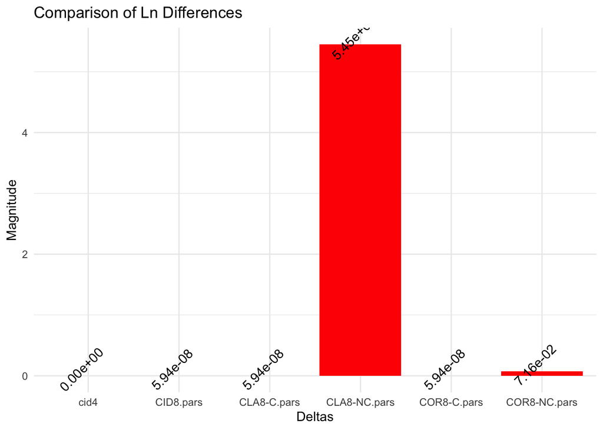

```r
# Create the plot
ggplot(delta_values, aes(x = Delta, y = Value, label = sprintf("%.2e", Value))) +
  geom_col(fill = c("blue", "blue", "blue", "blue", "red",  "red")) +
  geom_text(vjust = -0.5, angle = 45) +
  labs(title = "Comparison of Ln Differences", x = "Deltas", y = "Magnitude") +
  theme_minimal()
```

### Maximum Likelihood estimates

#### Likelihood table

```r
cor.pars <- tibble(
"N" = c(1:NSIM),
"cid4" = cid4,
"CID8"= get_item(CID8, 'lnLik'),
"COR8-C"= get_item(COR8_C, 'lnLik'),
"CLA8-C" = get_item(CLA8_C, 'lnLik'),
"COR8-NC" = get_item(COR8_NC, 'lnLik'),
"CLA8-NC" = append(get_item(CLA8_NC, 'lnLik'), NA, after=3),
)

kable(cor.pars, "html") %>%
  kable_styling(bootstrap_options = c("striped", "hover"))
```

| N | cid4 | CID8 | COR8-C | CLA8-C | COR8-NC | CLA8-NC |
| --- | --- | --- | --- | --- | --- | --- |
| 1 | -455.2889 | -455.2889 | -455.2889 | -455.2889 | -455.2656 | -447.5936 |
| 2 | -421.5108 | -421.5108 | -421.5108 | -421.5108 | -421.5105 | -419.1050 |
| 3 | -436.2586 | -436.2586 | -436.2586 | -436.2586 | -436.2568 | -430.3581 |
| 4 | -433.9500 | -433.9500 | -433.9500 | -433.9481 | -433.6760 | NA |
| 5 | -435.4874 | -435.4874 | -435.4874 | -435.4874 | -435.4863 | -425.5496 |
| 6 | -431.6472 | -431.6472 | -431.6472 | -431.6472 | -431.6454 | -427.5328 |
| 7 | -431.5324 | -431.5324 | -431.5324 | -431.5324 | -431.9977 | -420.6164 |
| 8 | -412.9655 | -412.9655 | -412.9655 | -412.9655 | -412.9655 | -410.8621 |
| 9 | -409.6720 | -409.6720 | -409.6720 | -409.6720 | -409.6255 | -405.0409 |
| 10 | -437.6128 | -437.6128 | -437.6128 | -437.6128 | -437.2857 | -428.2444 |

#### Mean absolute error

```r
dcor.pars <- tibble(
"cid4" = cid4,
"CID8"= get_item(CID8, 'lnLik'),
"COR8-C"= get_item(COR8_C, 'lnLik'),
"CLA8-C" = get_item(CLA8_C, 'lnLik'),
"COR8-NC" = get_item(COR8_NC, 'lnLik'),
"CLA8-NC" = append(get_item(CLA8_NC, 'lnLik'), NA, after=3),
)

# dcor.pars <- tibble(
# "cid4" = cid4,
# "CID8.pars"= CID8.pars %>% unlist,
# "COR8-C.pars"= COR8_C.pars %>% unlist,
# "CLA8-C.pars" = CLA8_C.pars %>% unlist,
# "COR8-NC.pars" = COR8_NC.pars %>% unlist,
# "CLA8-NC.pars" = CLA8_NC.pars %>% unlist,
# )
cid4t <- cid4
dcor.pars <- dcor.pars %>%
  mutate_all(~ abs(cid4t - .) )

column_means <- dcor.pars %>%
  summarise_all(~ mean(., na.rm = TRUE))

# Data
delta_values <- tibble(
  Delta = names(column_means),
  Value = column_means %>% slice(1) %>% unlist()
)



kable(column_means, "html") %>%
  kable_styling(bootstrap_options = c("striped", "hover"))
```

| cid4 | CID8 | COR8-C | CLA8-C | COR8-NC | CLA8-NC |
| --- | --- | --- | --- | --- | --- |
| 0 | 1e-07 | 1e-07 | 0.0002065 | 0.1141014 | 6.341424 |

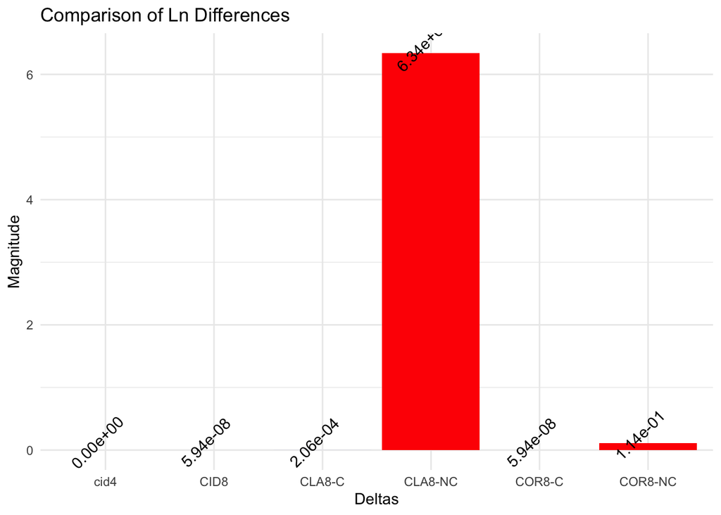

```r
# Create the plot
ggplot(delta_values, aes(x = Delta, y = Value, label = sprintf("%.2e", Value))) +
  geom_col(fill = c("blue", "blue", "blue", "blue", "red",  "red")) +
  geom_text(vjust = -0.5, angle = 45) +
  labs(title = "Comparison of Ln Differences", x = "Deltas", y = "Magnitude") +
  theme_minimal()
```

```r
library(dplyr)
library(tidyr)
delta_summary <- dcor.pars %>%
  dplyr::summarise(across(everything(),
    list(
      mean = ~mean(.x, na.rm = TRUE),
      sd   = ~sd(.x, na.rm = TRUE),
      median = ~median(.x, na.rm = TRUE),
      q25  = ~quantile(.x, 0.25, na.rm = TRUE),
      q75  = ~quantile(.x, 0.75, na.rm = TRUE),
      min  = ~min(.x, na.rm = TRUE),
      max  = ~max(.x, na.rm = TRUE)
    )
  )) %>%
  pivot_longer(
    everything(),
    names_to = c("Model", ".value"),
    names_sep = "_"
  )


print(delta_summary)
```

```
## # A tibble: 6 × 8
##   Model           mean          sd   median      q25      q75        min     max
##   <chr>          <dbl>       <dbl>    <dbl>    <dbl>    <dbl>      <dbl>   <dbl>
## 1 cid4    0            0           0        0        0        0          0
## 2 CID8    0.0000000594 0.000000179 5.68e-14 5.68e-14 1.56e-13 0          5.68e-7
## 3 COR8-C  0.0000000594 0.000000179 5.68e-14 5.68e-14 1.56e-13 0          5.68e-7
## 4 CLA8-C  0.000206     0.000590    8.39e- 7 8.53e-14 5.23e- 5 0          1.88e-3
## 5 COR8-NC 0.114        0.174       1.26e- 2 1.25e- 3 2.17e- 1 0.00000148 4.65e-1
## 6 CLA8-NC 6.34         3.29        5.90e+ 0 4.11e+ 0 9.37e+ 0 2.10       1.09e+1
```

```r
# saveRDS(delta_summary, 'R/tb-out/10-trees-CID-original.rds')
# readRDS('R/tb-out/10-trees-CID-original.rds')
```